# STA141A Course Project: Mind Reading Mice

Claire Hsieh

2023-04-28

# STA 141A Course Project: Mind Reading Mice

# Abstract

Data science involves the use of statistical and computational tools to extract meaningful information from often messy and convoluted sets of data. It can also be used to make additional predictions on new data based on models built from our given dataset. For this project, we are given data from experiments in the paper: *Distributed coding of choice, action and engagement across the mouse brain* and are tasked with predicting trial feedback given the neural activity of a mouse. To do this, we must carry out a basic data science pipeline: exploratory analysis, data integration, and predictive modeling. We will then be given an unlabeled dataset for which we must correctly predict feedback.

# Section 1 Introduction.

- Introduce the objective and briefly review the background of this data set.

The paper *Distributed coding of choice, action and engagement across the mouse brain* looked at the neuronal activity in four different mice as they made decisions based on visual contrast. The data includes each brain area’s spike activity over the trial period, the contrast of the stimuli, and the feedback which could be 1 or -1 corresponding to a right or wrong answer. The goal of this project is to correctly predict the feedback given data on neuronal activity, time, and contrast using various classification and prediction methods.

# Section 2 Exploratory analysis.

1. describe the data structures across sessions (e.g., number of neurons, number of trials, stimuli conditions, feedback types),

| mouse_name | date_exp | brain areas | neurons | trials | success_rate |
| --- | --- | --- | --- | --- | --- |
| Cori | 2016-12-14 | 8 | 734 | 114 | 0.61 |
| Cori | 2016-12-17 | 5 | 1070 | 251 | 0.63 |
| Cori | 2016-12-18 | 11 | 619 | 228 | 0.66 |
| Forssmann | 2017-11-01 | 11 | 1769 | 249 | 0.67 |
| Forssmann | 2017-11-02 | 10 | 1077 | 254 | 0.66 |
| Forssmann | 2017-11-04 | 5 | 1169 | 290 | 0.74 |
| Forssmann | 2017-11-05 | 8 | 584 | 252 | 0.67 |
| Hench | 2017-06-15 | 15 | 1157 | 250 | 0.64 |
| Hench | 2017-06-16 | 12 | 788 | 372 | 0.69 |
| Hench | 2017-06-17 | 13 | 1172 | 447 | 0.62 |
| Hench | 2017-06-18 | 6 | 857 | 342 | 0.80 |
| Lederberg | 2017-12-05 | 12 | 698 | 340 | 0.74 |
| Lederberg | 2017-12-06 | 15 | 983 | 300 | 0.80 |
| Lederberg | 2017-12-07 | 10 | 756 | 268 | 0.69 |
| Lederberg | 2017-12-08 | 8 | 743 | 404 | 0.76 |
| Lederberg | 2017-12-09 | 6 | 474 | 280 | 0.72 |
| Lederberg | 2017-12-10 | 6 | 565 | 224 | 0.83 |
| Lederberg | 2017-12-11 | 10 | 1090 | 216 | 0.81 |

- From the summary table, we can see that four mice were tested, each with varying number of trials and success rates. Of the four mice, Lederberg seems to have the higheset success rate.
- The stimuli conditions that the mice experiences are contrast on the left and right which can vary from 0 to 1. Feedback can be 1 for success and -1 for failure.

### Descriptive Statistics

|  | Cori | Forssmann | Hench | Lederberg |
| --- | --- | --- | --- | --- |
| average success | 0.63 | 0.69 | 0.69 | 0.76 |
| sd success | 0.03 | 0.04 | 0.08 | 0.05 |
| average brain areas | 8.00 | 8.50 | 11.50 | 9.57 |
| sd brain areas | 3.00 | 2.65 | 3.87 | 3.26 |
| average neurons | 807.67 | 1149.75 | 993.50 | 758.43 |
| sd neurons | 234.35 | 486.21 | 199.55 | 217.02 |
| average trials | 197.67 | 261.25 | 352.75 | 290.29 |
| sd trials | 73.36 | 19.28 | 81.50 | 65.84 |

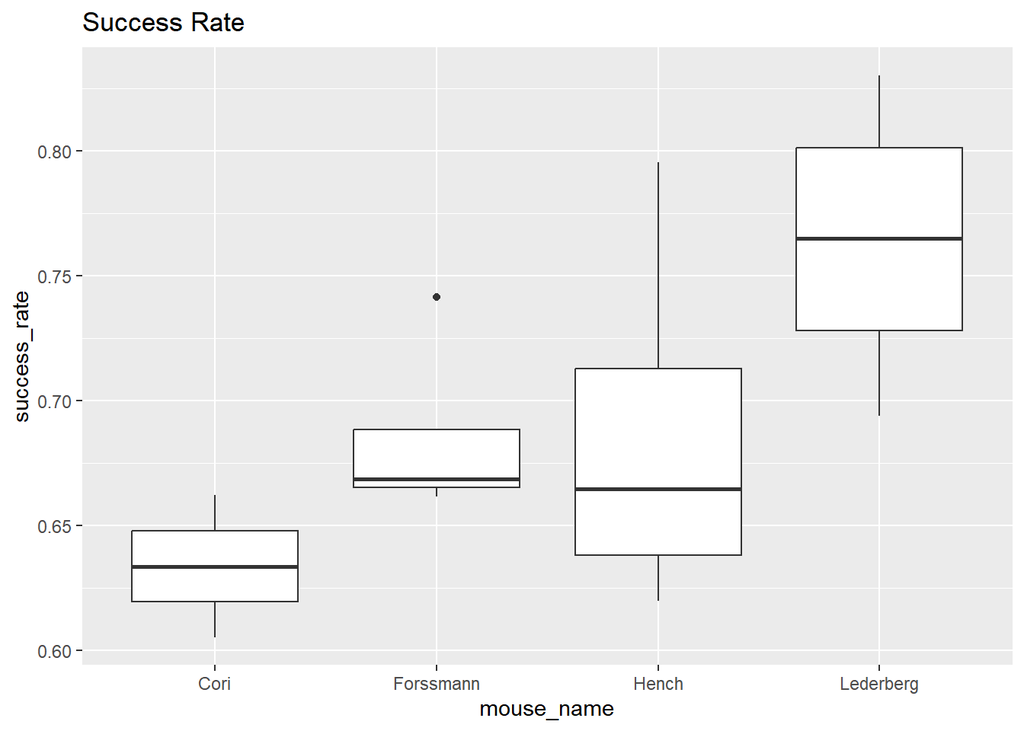

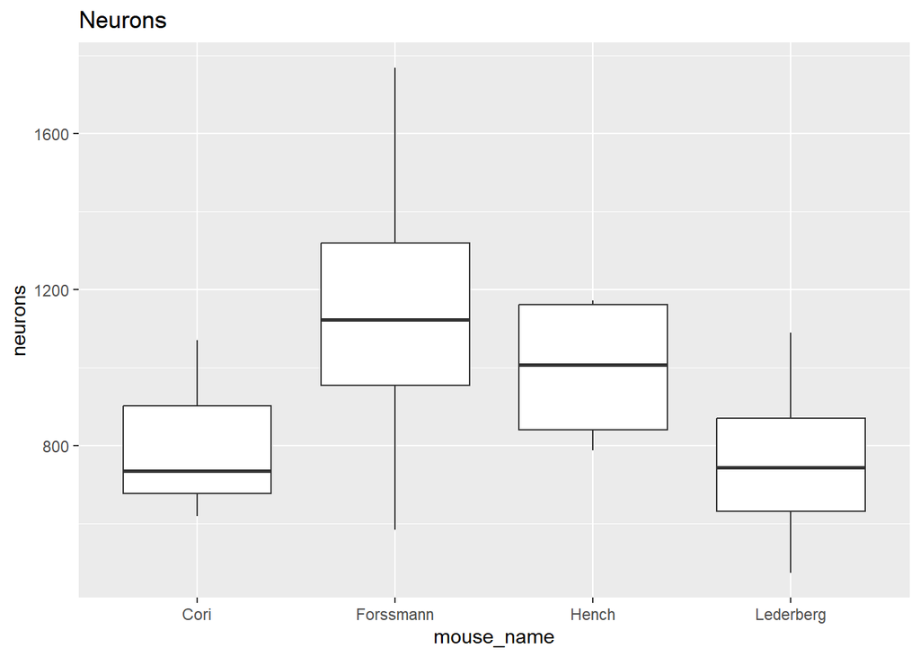

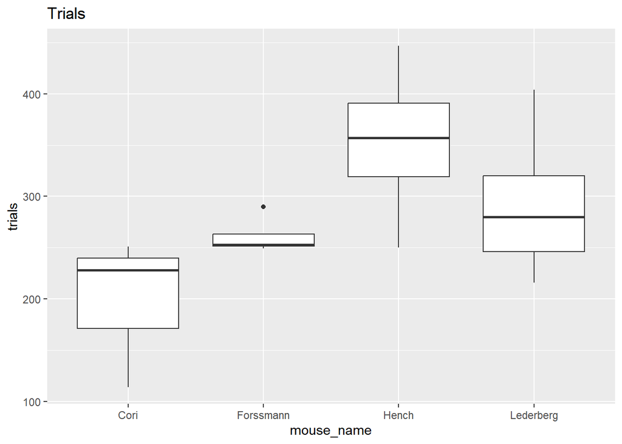

From these plots, we can see that Lederberg has a significantly higher success rate compared to the other mice. This could be important to note when we are creating predictive models as the neural activity of Lederberg may be more informative for accurately predicting feedback. We can see that Forssmann has the highest total number of neurons but this does not seem to affect its success rate, which implies that it is the identity of the brain area in which we see a spike that is correlated to the feedback.

2. explore the neural activities during each trial

```
##       LD      MEA     root       RT      VPL      VPM
## 4.166667 0.902439 1.072626 1.750000 1.660000 1.100000
```

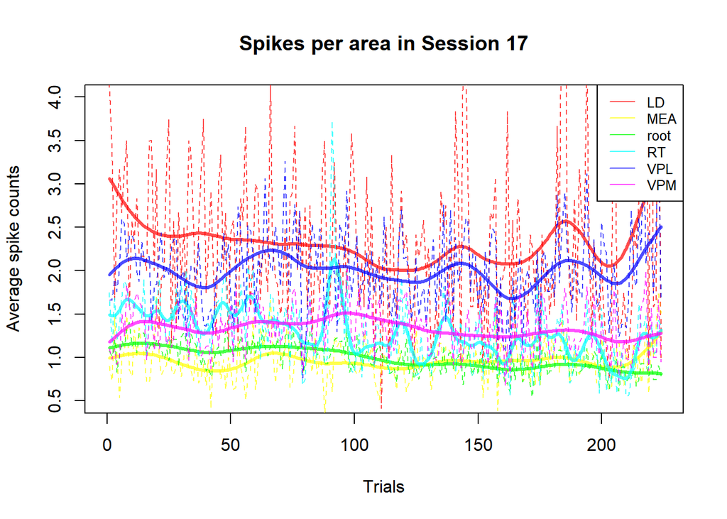

- This dotted lines of this graph shows the average spike count for each unique brain area of the Lederberg mice in session 17 and the solid lines are the smoothed average of the average spike counts. We can see that there is some correlation between the areas since MEA and root as well as LD and VPL seem to follow the same patterns. We can also see that there is somewhat of a trend towards the beginning and end of the trials where LD seems to increase.

3.explore the changes across trials

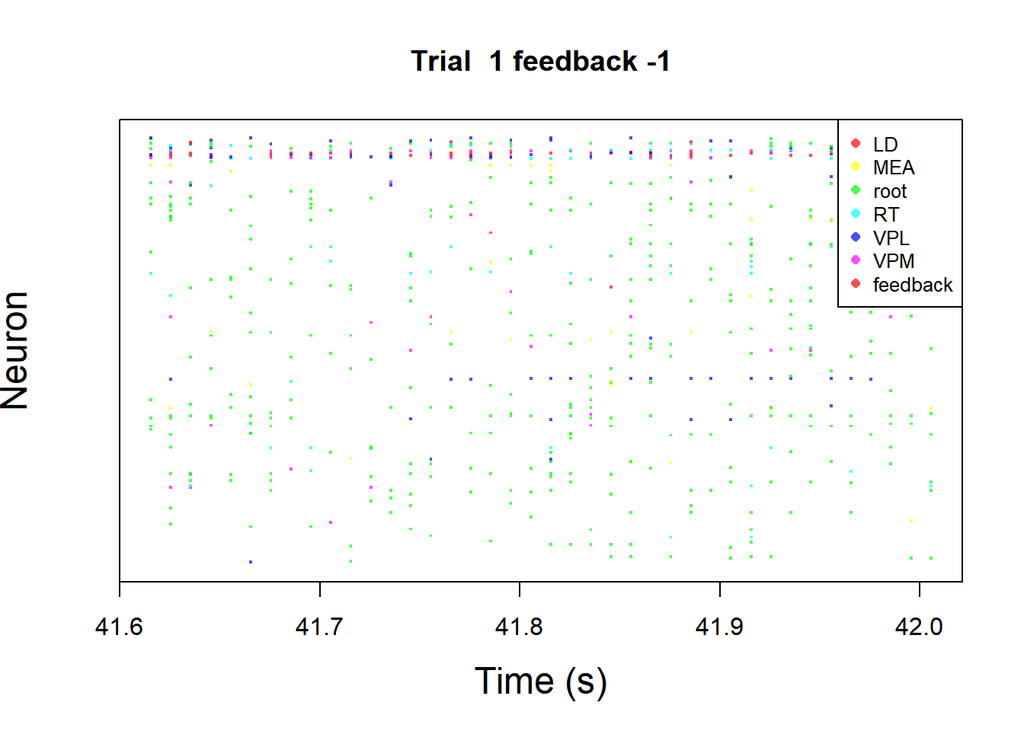

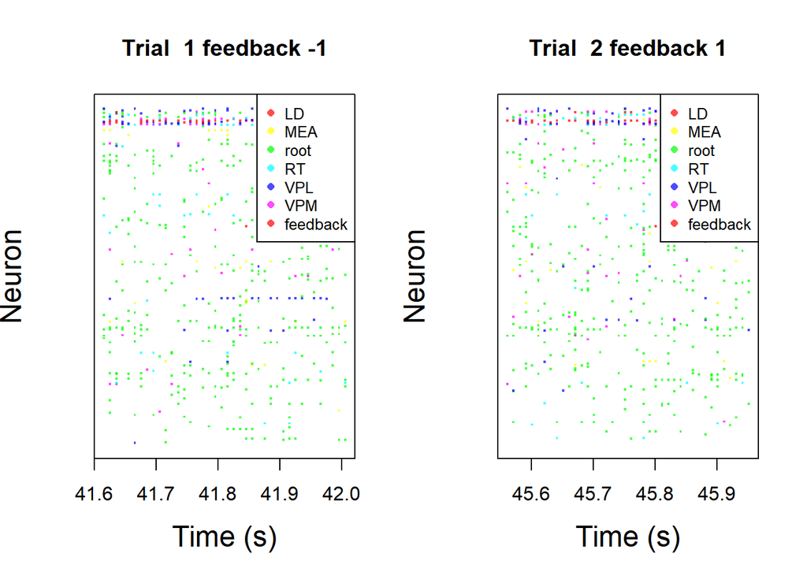

Every dot corresponds to a value on the spike vs time graph.

- We can see that the root neuron expression is much more common compared to the other neurons. We can also see that expression of other neurons occur less often but when they do occur, they seem to be constant across that trial.
4. explore homogeneity and heterogeneity across sessions and mice.

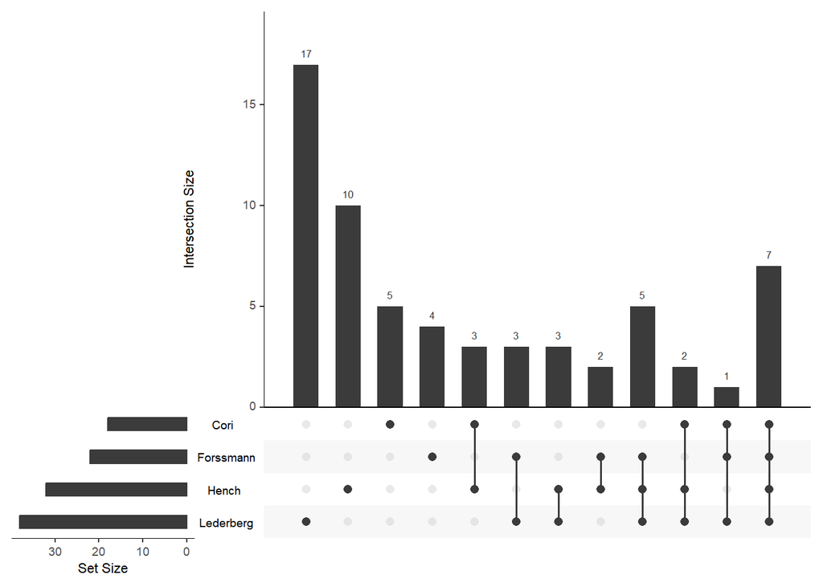

This graph shows the brain areas common among the different mice. We can see that Lederberg has the largest number of active brain sites and has a column with many neurons that are unique only to it (n=17). Cori has the smallest number of brain areas (as can be seen by the smaller set size on the left) and doesn’t have many unique brain areas. Forssmann and Hench both have many of the common brain areas as well as some other intersections as can be seen by many of the middle columns. This matches what we see in the average success rate of the four mice since Cori seems to have the lowest success rate and Lederberg the highest.

# Section 3 Data integration.

## Organizing brain area data by mouse

We are interested in predicting feedback based on mouse, the contrast of the trial, and the spike firing data of that trial. Based on the Time vs Neuron graph above, there does not appear to be much of a pattern in the timing of the spike firing. Data analysis would be much easier if we were to reduce the dimensions of the spike firing data from 2D (time vs spike) to 1D (spike) so I have decided to remove the time data. In addition, the paper frequently uses the spike firing *rate* when performing data analysis which similarly removes the time component from their data.

I will be creating a dataframe named `mouse.spk.freq` that contains the spike frequency for each brain area during each trial for all sessions. Even though we observe the activation of different brain areas throughout the different sessions, I believe it is acceptable to combine all the data into one dataframe since I will be using the *sum* of the spike frequencies in each trial. This means that 0’s correspond to not seeing the brain area at all and there would essentially be no difference between NA’s and 0’s.

| mouse_nm | feedback | contrast_right | contrast_left | ACA | MOs | LS | root | VISp | CA3 | SUB | DG | CA1 | VISl | VISpm | POST | VISam | MG | SPF | LP | MRN | NB | LGd | TH | VPL | VISa | LSr | OLF | ORB | PL | … |
| --- | --- | --- | --- | --- | --- | --- | --- | --- | --- | --- | --- | --- | --- | --- | --- | --- | --- | --- | --- | --- | --- | --- | --- | --- | --- | --- | --- | --- | --- | --- |
| Cori | 1 | 0.5 | 0.0 | 131 | 102 | 266 | 9 | 271 | 101 | 151 | 68 | 0 | 0 | 0 | 0 | 0 | 0 | 0 | 0 | 0 | 0 | 0 | 0 | 0 | 0 | 0 | 0 | 0 | 0 | … |
| Cori | 1 | 0.0 | 0.0 | 64 | 88 | 189 | 12 | 274 | 109 | 141 | 47 | 0 | 0 | 0 | 0 | 0 | 0 | 0 | 0 | 0 | 0 | 0 | 0 | 0 | 0 | 0 | 0 | 0 | 0 | … |
| Cori | -1 | 1.0 | 0.5 | 125 | 102 | 235 | 26 | 380 | 130 | 192 | 91 | 0 | 0 | 0 | 0 | 0 | 0 | 0 | 0 | 0 | 0 | 0 | 0 | 0 | 0 | 0 | 0 | 0 | 0 | … |
| Cori | -1 | 0.0 | 0.0 | 56 | 79 | 146 | 18 | 263 | 131 | 194 | 65 | 0 | 0 | 0 | 0 | 0 | 0 | 0 | 0 | 0 | 0 | 0 | 0 | 0 | 0 | 0 | 0 | 0 | 0 | … |
| Cori | -1 | 0.0 | 0.0 | 84 | 89 | 180 | 12 | 269 | 114 | 161 | 57 | 0 | 0 | 0 | 0 | 0 | 0 | 0 | 0 | 0 | 0 | 0 | 0 | 0 | 0 | 0 | 0 | 0 | 0 | … |
| Cori | 1 | 0.0 | 0.0 | 49 | 82 | 124 | 10 | 206 | 114 | 132 | 30 | 0 | 0 | 0 | 0 | 0 | 0 | 0 | 0 | 0 | 0 | 0 | 0 | 0 | 0 | 0 | 0 | 0 | 0 | … |

### Visualizing patterns in our data

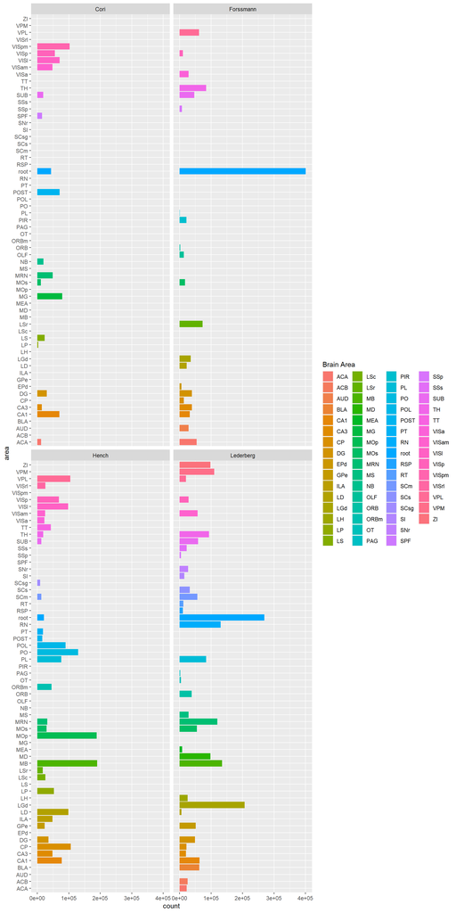

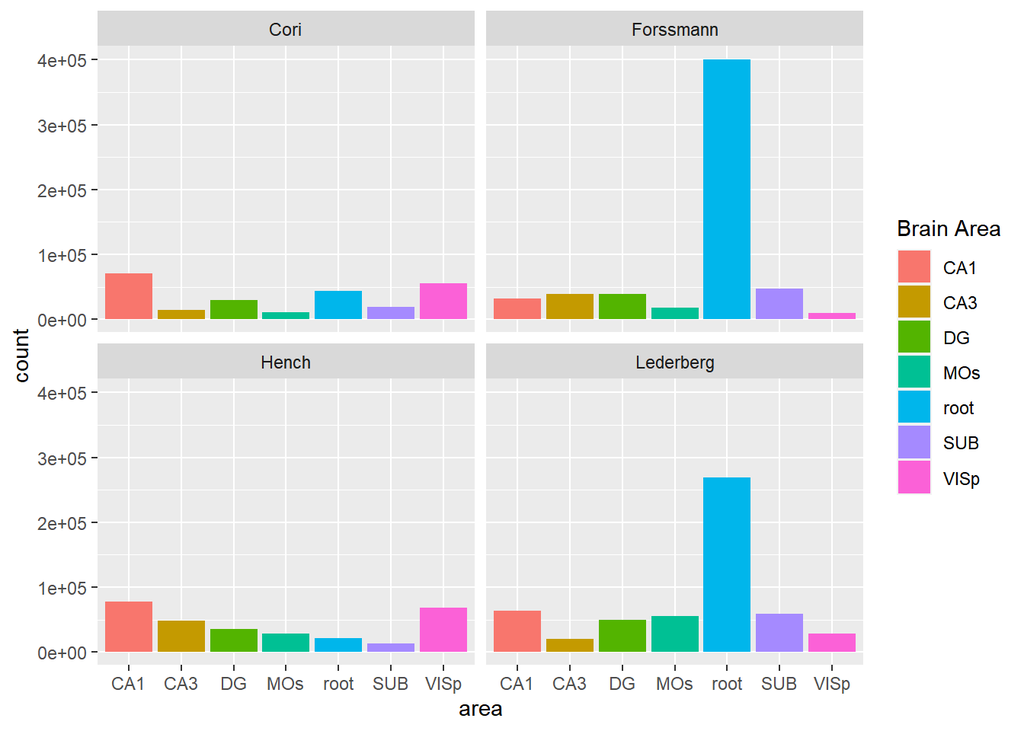

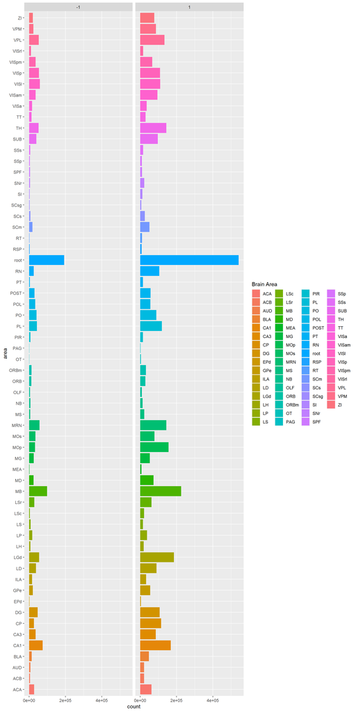

Based on this graph of the distribution of brain area activation based on feedback, we can see that in trails with positive feedback, there is overall greater brain area activation compared to trials with negative feedback even if the distribution is similar. From this we can infer that it is likely not the specific brain areas that are correlated with feedback but rather, the number of spikes in each trail, regardless of the brain area where they’re found.

### Data Cleaning

```
## $linearCombos
## list()
##
## $remove
## NULL
```

Since the goal of this project is to predict feedback using brain areas, linearly dependent columns would not be useful in our models as they would not provide any new information and should therefore be removed to reduce the complexity of our model. We do not see any linearly dependent columns in our dataset.

```
##
##   -1    1
## 1473 3608
```

We can see that there is a greater number of trials with positive compared to negative feedback. This is important to note as having imbalanced classes could compromise our models if we do not address this problem either when building the model or when sampling.

## Dimension Reduction

The purpose of Dimension Reduction is to find any useful patterns in the data or to simply our models by filtering out useful predictor variables. I will be PCA to find informative predictor variables.

### PCA

I will perform PCA on each of the different mice to see if they share the same brain areas that could be used in a prediction model.

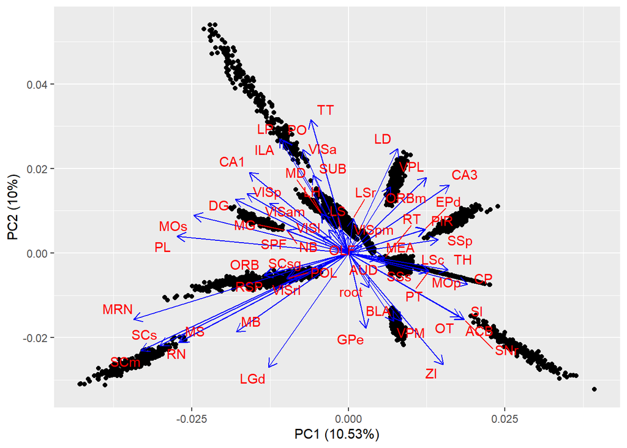

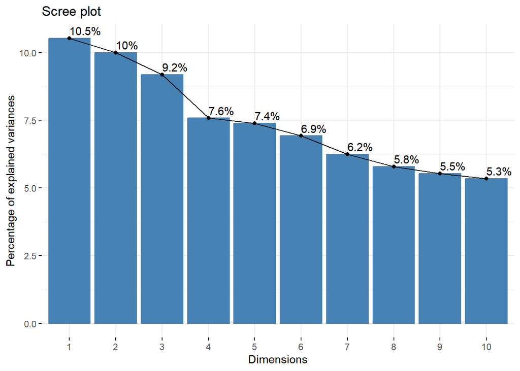

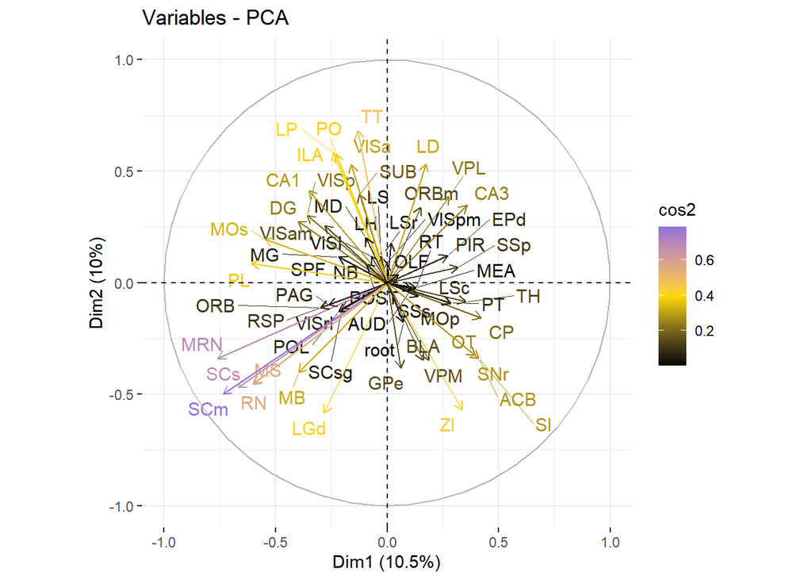

When we perform PCA, one brain area stands out on the cos2 plot. The cos2 plot shows the importance of each vector in creating the PCs. Principle components seek to explain variation in data by combining predictor variables.

The PCs generated by PCA do not appear useful as each PC seems to explain an equal amount of variance in our data. Based on the scree plot, it is difficult to determine the number of PCs we should include in our model. Therefore I will not be using the PCs generated by PCA for modeling as they do not appear to be an improvement upon using the given brain areas as predictors. In addition, PCs are more difficult to interpret as they are a combination of the brain areas.

# Section 4 Predictive modeling.

Finally, I will build a prediction model to predict the outcome (i.e., feedback types). Since we have access to labeled data, it would be best to choose supervised machine learning models as they generally outperform unsupervised models in terms of accuracy. I will test a few different types of models including:

1. **Gradient Descent Based Algorithms**: Gradient descent based algorithms try to minimize the standard error of the model in steps.
- Logistic regression: I chose to use logistic regression because this model is ideal for classifying binary data. Logistic regression also explains its choice in classification because it uses a maximum likelihood estimation to generate the probability of trials being in certain classes, then classifying based on those probabilities.
2. **Dimensionality Reduction**: Dimensionality reduction algorithms seek to reduce the number of features of a model, while keeping features that retain the most information in the dataset.
- Linear Discriminant Analysis (LDA): Since we have so many potential predictor variables, LDA could be useful in removing several, uninformative predictors.
3. **Distance based algorithms**: Distance based algorithms attempt to classify data based on their relative distances.
- k-nearest neighbors (knn): knn is an unsupervised learning model, works well on non-linear data, and may allow us to determine the importance of different variables on predicting feedback.
- Support Vector Machine (SVM): SVM is a supervised model and performs well in high dimensional spaces (when there is a large number of parameters).
4. **Tree based algorithms**: Tree based algorithms classify data using decision trees.
- Random forest: Random forest tends to be highly accurate and handles outliers and noise well, though it may be computationally intensive.

The performance of my models will be compared to a benchmark model of 330 trials based on session 1 and session 18.

## Create Training and Testing Dataset Using Split-Sample Validation

For one of the models I plan on using (LDA), there is an assumption that the data has a normal distribution and for that reason I will first normalize my data.

Because our dataset has more positive than negative feedback, our dataset is imbalanced and will therefore perform better when predicting positive feedback. To address this issue, I have upsampled the training dataset so that there is an equal number of both positive and negative feedback.

## Building a Model

Since unsupervised learning is not very useful for classifying or making predictions, it would be more useful to use supervised learning which takes labeled data (feedback) and uses it to train a model to make predictions based on brain areas.

### Benchmark

For the benchmark model, I created a logistic regression model using the data extracted from session 1 and 18 to create a benchmark training set then tested this model on the same test set I use for the other models.

```
## Confusion Matrix and Statistics
##
##           Reference
## Prediction   0   1
##          0 271   6
##          1 714  26
##
##                Accuracy : 0.292
##                  95% CI : (0.2642, 0.321)
##     No Information Rate : 0.9685
##     P-Value [Acc > NIR] : 1
##
##                   Kappa : 0.0075
##
##  Mcnemar's Test P-Value : <2e-16
##
##             Sensitivity : 0.27513
##             Specificity : 0.81250
##          Pos Pred Value : 0.97834
##          Neg Pred Value : 0.03514
##               Precision : 0.97834
##                  Recall : 0.27513
##                      F1 : 0.42948
##              Prevalence : 0.96853
##          Detection Rate : 0.26647
##    Detection Prevalence : 0.27237
##       Balanced Accuracy : 0.54381
##
##        'Positive' Class : 0
##
```

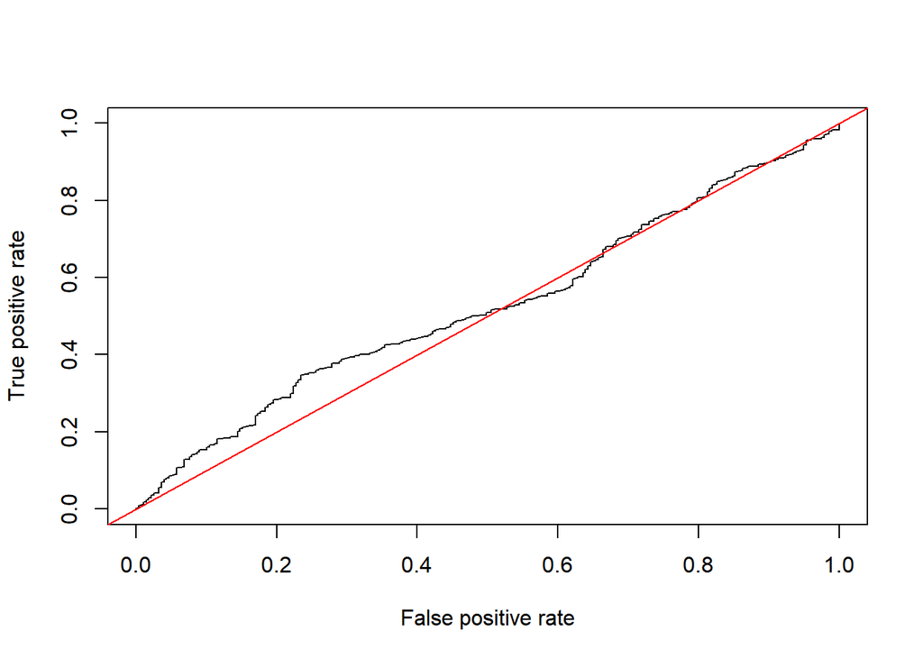

```
## Area under the curve: 0.5267
```

### Logistic Regression

```
## Confusion Matrix and Statistics
##
##           Reference
## Prediction   0   1
##          0 173 104
##          1 289 451
##
##                Accuracy : 0.6136
##                  95% CI : (0.5829, 0.6436)
##     No Information Rate : 0.5457
##     P-Value [Acc > NIR] : 7.204e-06
##
##                   Kappa : 0.1936
##
##  Mcnemar's Test P-Value : < 2.2e-16
##
##             Sensitivity : 0.3745
##             Specificity : 0.8126
##          Pos Pred Value : 0.6245
##          Neg Pred Value : 0.6095
##               Precision : 0.6245
##                  Recall : 0.3745
##                      F1 : 0.4682
##              Prevalence : 0.4543
##          Detection Rate : 0.1701
##    Detection Prevalence : 0.2724
##       Balanced Accuracy : 0.5935
##
##        'Positive' Class : 0
##
```

I chose to use a logistic regression model because it is well suited for categorical data and since the data I am trying to classify is binary, this will be an especially simple model to create. Logistic regression is a classification algorithm and will give us the probabilities of samples belonging to certain classes or having certain algorithms. Therefore it is up to us to choose a probability cutoff for a sample belonging to a certain class. This can be done with a variety of algorithms or the cutoff can simply be set to 50% since our predicted variable is binary. Ideally though, we should choose a cutoff that maximizes the sensitivity-specificity metric.

The miscalculation rate of our logistic regression model on a normalized training and testing dataset depends on the training and testing dataset so after performing logistic regression on 100 different training and testing datasets, our average accuracy is 59.72%. Given that our data only has two possible outcomes (0 and 1), the expected accuracy is 50%, which means our model is somewhat better than random chance.

#### Sensitivity Analysis

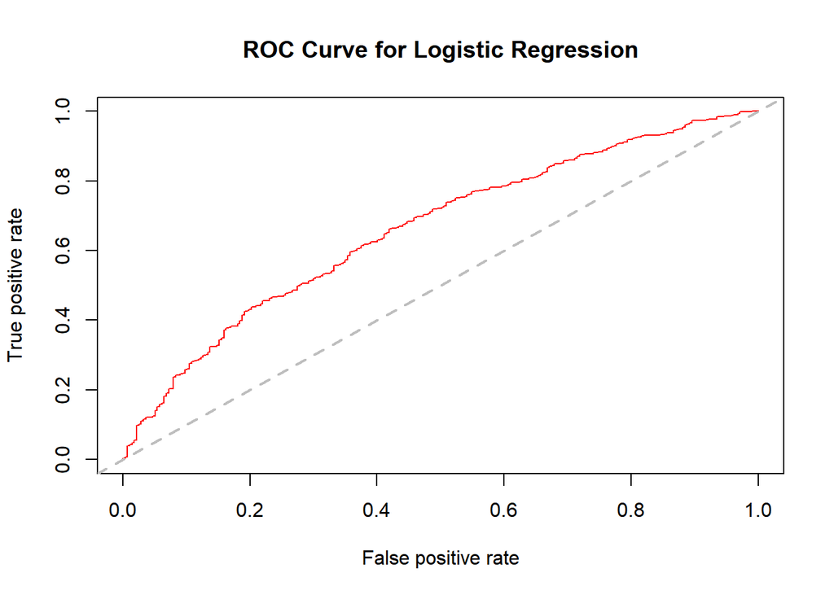

```
## Area under the curve: 0.6606
```

```
##
##   Precision-recall curve
##
##     Area under curve (Integral):
##      0.6763852
##
##     Area under curve (Davis & Goadrich):
##      0.6763844
##
##     Curve for scores from  0.1152174  to  0.9599736
##     ( can be plotted with plot(x) )
```

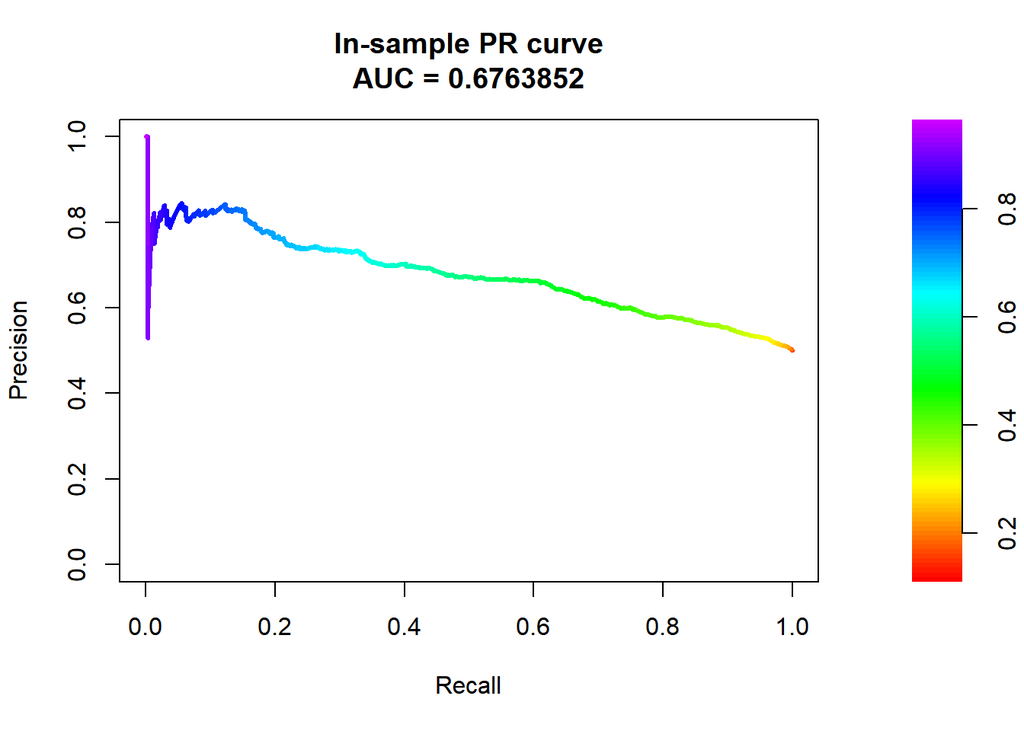

```
##
##   Precision-recall curve
##
##     Area under curve (Integral):
##      0.827538
##
##     Area under curve (Davis & Goadrich):
##      0.8275292
##
##     Curve for scores from  0.09694198  to  0.9498193
##     ( can be plotted with plot(x) )
```

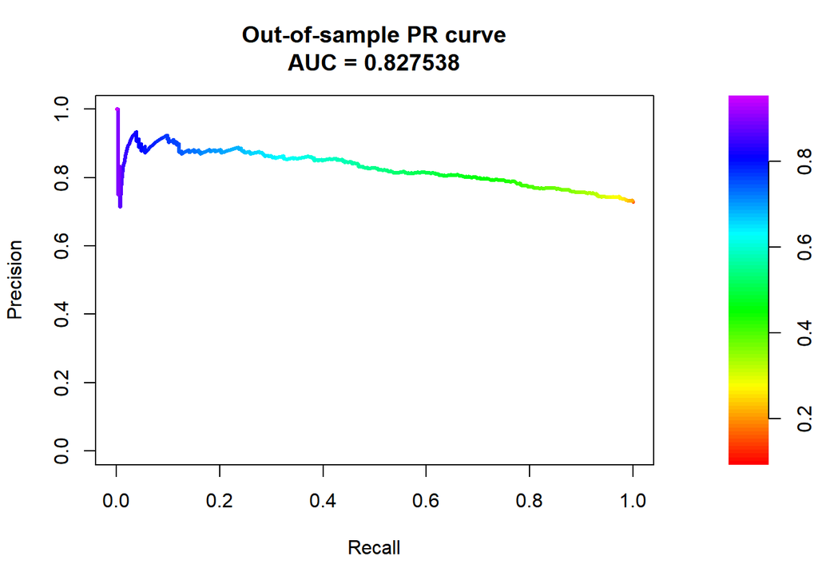

#### Interaction term

Because a mouse is choosing between two contrasts on the left and right, there will be an interaction between the contrast_left and contrast_right variable, especially if both are non-zero at the same time. If a mouse has to choose between two non-zero contrasts, the difficulty of the trial will be greater, and the chance of negative feedback will also be greater. Therefore we should also include an interaction term between left and right contrast. It would also make sense to include interaction terms between brain areas that are in the same brain region (ie visual cortex) but because there are so many brain areas, including interaction terms for all of them, might make the model unnecessarily complex.

```
## Confusion Matrix and Statistics
##
##           Reference
## Prediction   0   1
##          0 171 106
##          1 290 450
##
##                Accuracy : 0.6106
##                  95% CI : (0.5799, 0.6407)
##     No Information Rate : 0.5467
##     P-Value [Acc > NIR] : 2.218e-05
##
##                   Kappa : 0.1866
##
##  Mcnemar's Test P-Value : < 2.2e-16
##
##             Sensitivity : 0.3709
##             Specificity : 0.8094
##          Pos Pred Value : 0.6173
##          Neg Pred Value : 0.6081
##               Precision : 0.6173
##                  Recall : 0.3709
##                      F1 : 0.4634
##              Prevalence : 0.4533
##          Detection Rate : 0.1681
##    Detection Prevalence : 0.2724
##       Balanced Accuracy : 0.5901
##
##        'Positive' Class : 0
##
```

### Linear Discreminant Analysis (LDA)

```
## Confusion Matrix and Statistics
##
##           Reference
## Prediction   0   1
##          0 175 102
##          1 291 449
##
##                Accuracy : 0.6136
##                  95% CI : (0.5829, 0.6436)
##     No Information Rate : 0.5418
##     P-Value [Acc > NIR] : 2.238e-06
##
##                   Kappa : 0.1966
##
##  Mcnemar's Test P-Value : < 2.2e-16
##
##             Sensitivity : 0.3755
##             Specificity : 0.8149
##          Pos Pred Value : 0.6318
##          Neg Pred Value : 0.6068
##               Precision : 0.6318
##                  Recall : 0.3755
##                      F1 : 0.4711
##              Prevalence : 0.4582
##          Detection Rate : 0.1721
##    Detection Prevalence : 0.2724
##       Balanced Accuracy : 0.5952
##
##        'Positive' Class : 0
##
```

#### Sensitivity Analysis

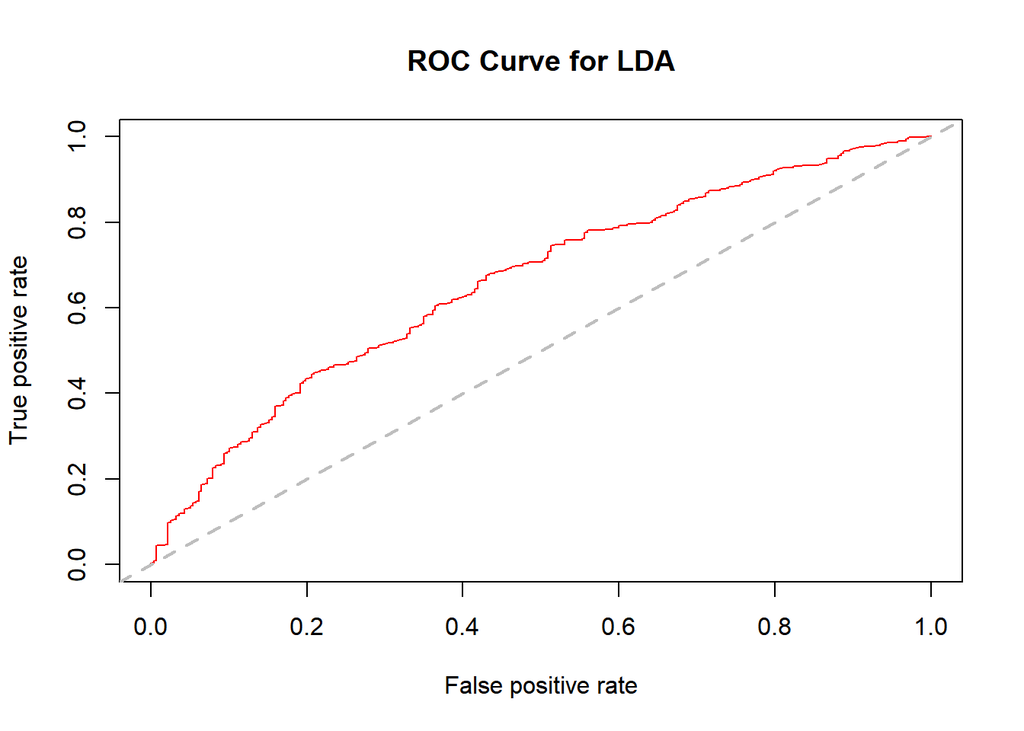

```
## Area under the curve: 0.66
```

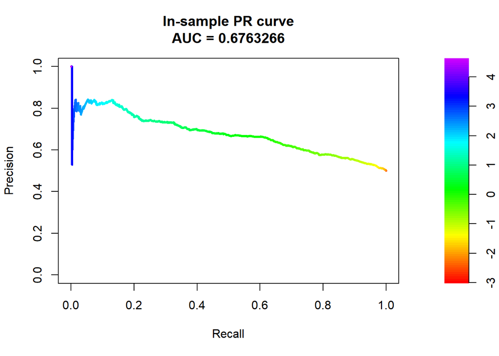

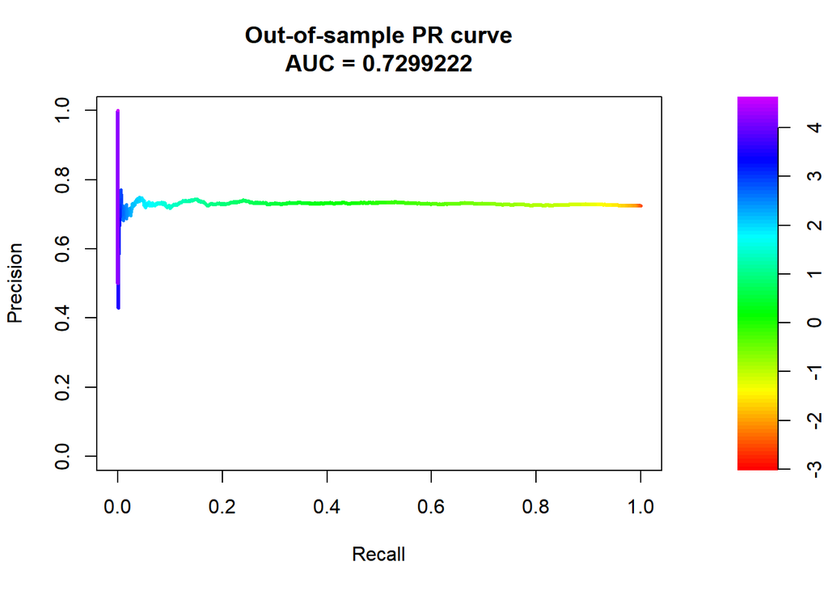

### k-Nearest Neighbors (knn)

knn is a non-parametric algorithm meaning it will perform well if our data is non linear. Non-parametric algorithms make “no assumptions … about the shape of the decision boundary”. [30] knn works by computing the distance between each datapoint to all other points then selecting k number of nearest neighbors and classifies based on the most frequent label.

We will first perform k-fold cross validation to determine the ideal k to be used for our knn model. k-fold Cross Validation is a technique used to evaluate the performance of a model by splitting the data into k subsets and training the model on k-1 subsets and testing it on the remaining subset. This is repeated k times and the average accuracy is calculated.

```
## k-Nearest Neighbors
##
## 5081 samples
##   64 predictor
##    2 classes: 'X0', 'X1'
##
## Pre-processing: centered (64), scaled (64)
## Resampling: Cross-Validated (10 fold, repeated 5 times)
## Summary of sample sizes: 4574, 4573, 4573, 4572, 4573, 4573, ...
## Resampling results across tuning parameters:
##
##   k   ROC        Sens       Spec
##    5  0.6952167  0.3474554  0.8687338
##    7  0.7063585  0.3243878  0.8810948
##    9  0.7090614  0.3011693  0.8925142
##   11  0.7135348  0.2848805  0.9025499
##   13  0.7155415  0.2679114  0.9100869
##   15  0.7161001  0.2552767  0.9154654
##   17  0.7160898  0.2430502  0.9207870
##   19  0.7158095  0.2283949  0.9285482
##   21  0.7155019  0.2145477  0.9318172
##   23  0.7140924  0.2053034  0.9363633
##   25  0.7124003  0.1941800  0.9393002
##   27  0.7105269  0.1892931  0.9420154
##   29  0.7094874  0.1820905  0.9456731
##   31  0.7085512  0.1755690  0.9477799
##   33  0.7066219  0.1712282  0.9492205
##   35  0.7052254  0.1664745  0.9524358
##   37  0.7046816  0.1625363  0.9545977
##   39  0.7031522  0.1560186  0.9568704
##   41  0.7006932  0.1550616  0.9585346
##   43  0.6974674  0.1499007  0.9607515
##
## ROC was used to select the optimal model using the largest value.
## The final value used for the model was k = 15.
```

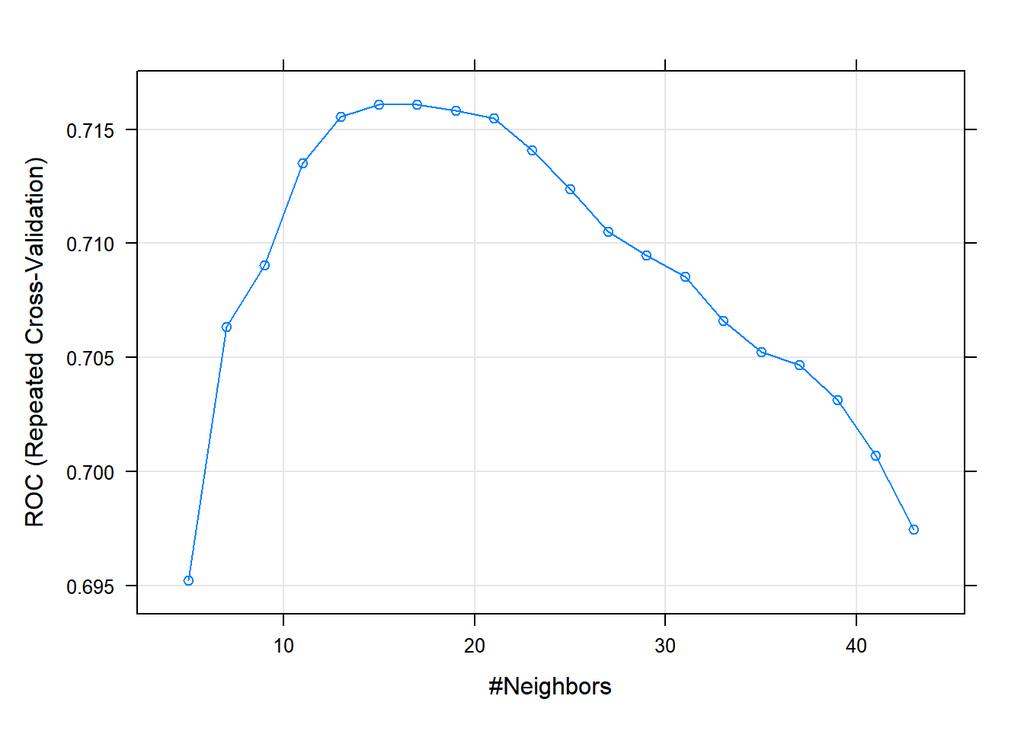

```
## Confusion Matrix and Statistics
##
##           Reference
## Prediction   0   1
##          0  87 190
##          1  50 690
##
##                Accuracy : 0.764
##                  95% CI : (0.7367, 0.7898)
##     No Information Rate : 0.8653
##     P-Value [Acc > NIR] : 1
##
##                   Kappa : 0.2928
##
##  Mcnemar's Test P-Value : <2e-16
##
##             Sensitivity : 0.63504
##             Specificity : 0.78409
##          Pos Pred Value : 0.31408
##          Neg Pred Value : 0.93243
##               Precision : 0.31408
##                  Recall : 0.63504
##                      F1 : 0.42029
##              Prevalence : 0.13471
##          Detection Rate : 0.08555
##    Detection Prevalence : 0.27237
##       Balanced Accuracy : 0.70956
##
##        'Positive' Class : 0
##
```

Here, I use ROC (repeated cross validation) as the metric used to train the knn model. ROC is a bootstrapping method that allows the training dataset given to the model to be further split into training and testing datasets that will be used to improve the model. This spliting and training will then be done some specified number of times. Here I have decided to have the model repeat this process 5 times. Tune length species the number of tuning parameters the model should try to obtain the best performance. For a knn model, one of the most important parameters is k or the number of nearest neighbors and the `trainControl` will automatically select these parameters for us.

Because knn “relies on observable data similarities and sophisticated distance metrics to generate accurate predictions” [29], it does not require a training dataset and so I simply used the normalized mouse dataset to generate the model. The normalization step might not be required as the training function will likely preprocess the dataset anyway.

#### Sensitivity Analysis

```
## A performance instance
##   'Area under the ROC curve'
```

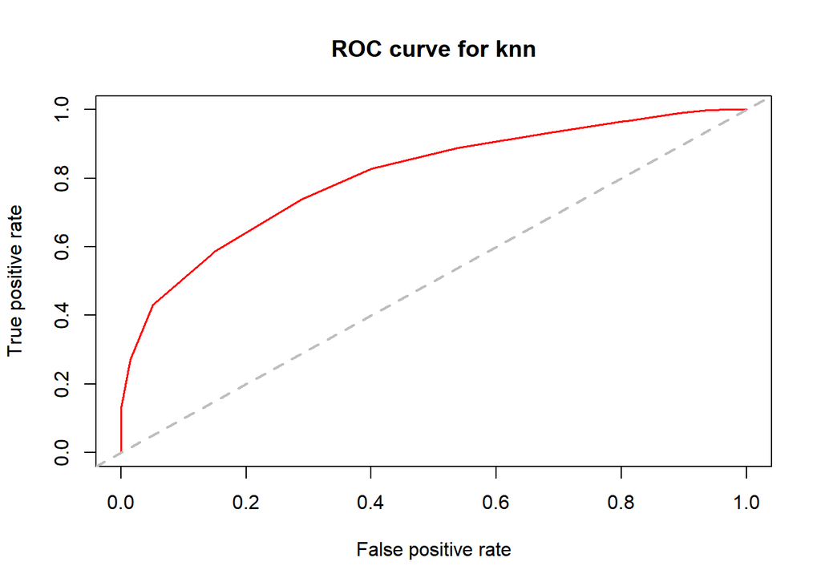

[output not shown]

### Random Forest

Random forest is a machine learning model similar to decision trees but with the addition of bootstrapping to generate multiple sample datasets. Bootstrapping will select a pre-determined number of datapoints with replacement which may leave out certain datapoints. The datapoints that are not included in the training data are used to determine the out of bag error rate (OOB) which is the error rate of the random forest model on these datapoints. To select mtry (number of features to consider at each split point), we use the OOB as a cost function, and attempt to select the mtry that minimizes the OOB.

The random forest model does not have underlying assumptions about the data and therefore have increased flexibility and possibly accuracy compared to regression models (logistic regression) and overcomes the issue of over-fitting that is common with decision trees. Random forest models are also simpler to interpret compared to other non parametric models as it is essentially an amalgamation of decision trees which explain the decisions for classification based on each node. This allows us to generate a feature importance plot which tells us the importance of each feature for predictions.

```
## mtry = 8  OOB error = 19.23%
## Searching left ...
## mtry = 6     OOB error = 23.95%
## -0.2456936 0.01
## Searching right ...
## mtry = 12    OOB error = 13.21%
## 0.3127833 0.01
## mtry = 18    OOB error = 11.05%
## 0.1635884 0.01
## mtry = 27    OOB error = 10.91%
## 0.0126183 0.01
## mtry = 40    OOB error = 10.97%
## -0.004792332 0.01
```

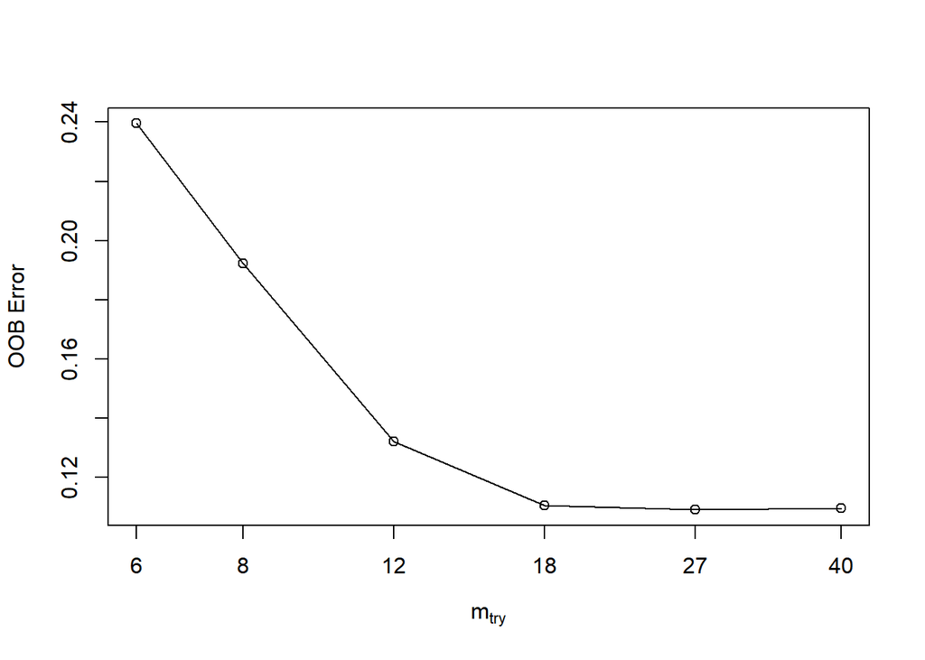

```
##        mtry  OOBError
## 6.OOB     6 0.2395397
## 8.OOB     8 0.1922943
## 12.OOB   12 0.1321478
## 18.OOB   18 0.1105300
## 27.OOB   27 0.1091353
## 40.OOB   40 0.1096583
```

```
## [1] 27
```

```
##
## Call:
##  randomForest(formula = as.factor(feedback) ~ ., data = mouse.train,      mtry = best.m, importance = TRUE, ntree = 500)
##                Type of random forest: classification
##                      Number of trees: 500
## No. of variables tried at each split: 27
##
##         OOB estimate of  error rate: 10.83%
## Confusion matrix:
##      0    1 class.error
## 0 2702  166  0.05788006
## 1  455 2413  0.15864714
```

```
##                         0          1 MeanDecreaseAccuracy MeanDecreaseGini
## contrast_right 100.753661 39.6913554            104.74921       115.250784
## contrast_left   75.684907 27.4859231             77.28532       138.069206
## ACA             30.151325  5.7383437             34.63582        46.963882
## MOs             41.405312 10.1229793             43.92858        66.726930
## LS              13.035580 13.2217735             20.64867        13.259119
## root            66.856048 31.5256848             73.85416       240.322101
## VISp            30.117554 10.9138988             29.68206        96.728547
## CA3             46.202344 12.9405059             48.08233        92.329981
## SUB             30.782245 10.9695646             33.47599        49.904853
## DG              41.349286 11.4973277             45.87081        87.842819
## CA1             47.172962 14.9389501             48.36307       149.084295
## VISl            26.030914  9.0362201             25.61406        60.289705
## VISpm           27.591535  2.2667126             33.42184        24.295309
## POST            21.722812 11.0374859             21.84376        59.476198
## VISam           29.536861 23.5903129             41.07600        64.054910
## MG              17.300230  9.8955488             22.64945        14.431930
## SPF             16.723560  0.9335502             18.46719         8.675479
## LP              20.547260  4.6173847             22.30968        21.332296
## MRN             38.802498 15.3326642             47.61709        61.223342
## NB              16.704573  1.4907222             18.69134         8.177328
## LGd             32.828083 18.8863768             38.29858        91.693468
## TH              41.933570 11.3904154             43.48762        81.568524
## VPL             43.911068 11.8184528             50.25191        70.431748
## VISa            28.555887 16.0069966             35.69261        45.419315
## LSr             32.270467 15.4408336             39.51908        53.861513
## OLF             15.936466  5.6790616             20.75269        12.687477
## ORB             29.560765 -3.9803923             28.99192        23.700584
## PL              39.615671 13.6712607             41.48038        62.588830
## AUD             30.804100  1.8465754             31.43127        33.335012
## SSp             41.968923 -3.7293258             43.91669        54.161692
## LD              43.990941  7.9923895             47.31531        63.575527
## CP              40.213631 16.3204804             41.37391        59.645967
## EPd             20.725674 -5.6170731             22.73696        13.535448
## PIR             20.545628 10.8149829             26.87710        18.882555
## ILA              9.317115  5.0839746             12.67237         6.679612
## TT              26.454758  8.2242046             31.73651        23.952744
## PO              15.507020  4.2822585             16.75744         9.941190
## ORBm            16.304532 17.0168247             23.34635        18.118425
## MB              29.511049 14.3544321             34.60437        68.347227
```

[output cut: 10 more lines]

```
## ZI              22.806871 11.0981826             24.32759        51.486010
## SCs             22.186836 14.2093580             26.10059        26.046913
## RN              11.934015 18.4285227             20.65876        10.769459
## MS              19.432338 -0.7439760             17.23832         8.148800
## RSP             22.243321  9.0193631             26.06794        18.371852
## PAG             13.257756  9.1575666             18.13523         8.667697
## BLA             28.251505  8.6953625             31.71952        23.897564
## VPM             30.695863 21.8557599             46.56890        62.642372
## SSs             35.019421 18.3191618             45.78053        42.495326
## RT              24.953934  4.7711002             22.41079        16.700744
## MEA             19.095326  7.3477138             19.16530        15.538611
## ACB             14.556893 10.8866605             18.49052         9.621238
## OT              15.145775 10.8720347             17.66502        10.736706
## SI              18.231997  2.1249342             18.31314         8.882725
## SNr             12.961729  8.2096648             16.10419        11.337809
```

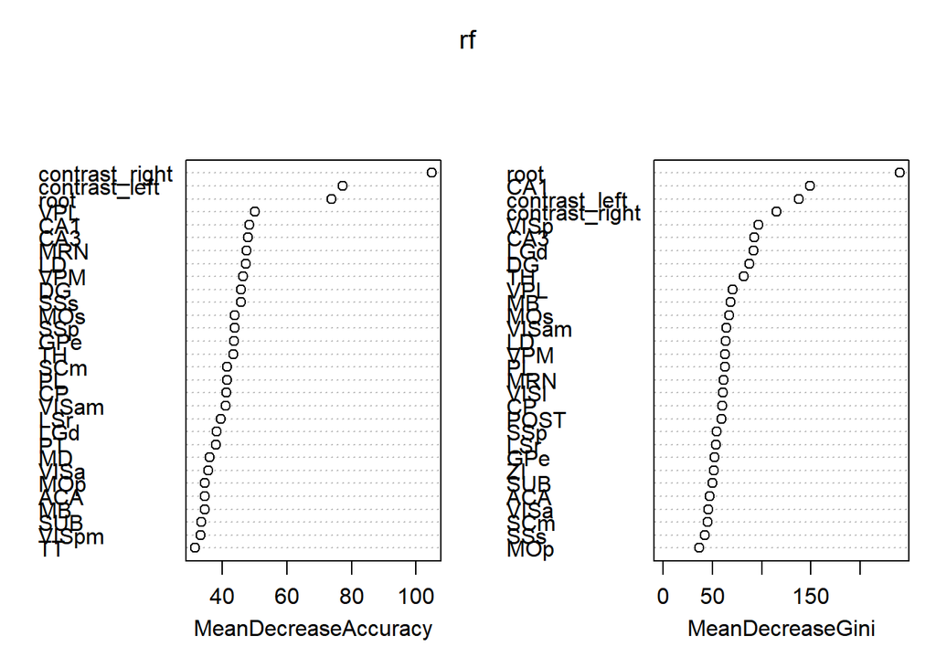

```
## Confusion Matrix and Statistics
##
##           Reference
## Prediction   0   1
##          0 113 164
##          1 114 626
##
##                Accuracy : 0.7266
##                  95% CI : (0.6981, 0.7538)
##     No Information Rate : 0.7768
##     P-Value [Acc > NIR] : 0.999925
##
##                   Kappa : 0.2691
##
##  Mcnemar's Test P-Value : 0.003295
##
##             Sensitivity : 0.4978
##             Specificity : 0.7924
##          Pos Pred Value : 0.4079
##          Neg Pred Value : 0.8459
##               Precision : 0.4079
##                  Recall : 0.4978
##                      F1 : 0.4484
##              Prevalence : 0.2232
##          Detection Rate : 0.1111
##    Detection Prevalence : 0.2724
##       Balanced Accuracy : 0.6451
##
##        'Positive' Class : 0
##
```

#### Sensitivity Analysis

```
## A performance instance
##   'Area under the ROC curve'
```

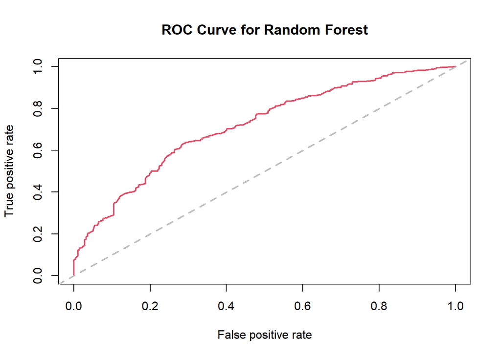

```
## Area under the curve: 0.6269
```

### Support Vector Machine (SVM)

SVMs work by projecting data into a higher dimensional space, where it will then find a hyperplane that can accurately seperate the points while maximizing margins. Different kernels can be selected (kernel function) for how the data is mapped into the higher dimensional space. Here I have chosen radial basis function (RBF) because it is better at handling nonlinear relationships between class and predictor variables. [26] I also chose to use C-classification as the SVM type as our goal is to use this model to classify feedback.

```
## Confusion Matrix and Statistics
##
##           Reference
## Prediction   0   1
##          0 168 109
##          1 247 493
##
##                Accuracy : 0.65
##                  95% CI : (0.6197, 0.6793)
##     No Information Rate : 0.5919
##     P-Value [Acc > NIR] : 8.415e-05
##
##                   Kappa : 0.2359
##
##  Mcnemar's Test P-Value : 3.843e-13
##
##             Sensitivity : 0.4048
##             Specificity : 0.8189
##          Pos Pred Value : 0.6065
##          Neg Pred Value : 0.6662
##               Precision : 0.6065
##                  Recall : 0.4048
##                      F1 : 0.4855
##              Prevalence : 0.4081
##          Detection Rate : 0.1652
##    Detection Prevalence : 0.2724
##       Balanced Accuracy : 0.6119
##
##        'Positive' Class : 0
##
```

#### Sensitivity Analysis

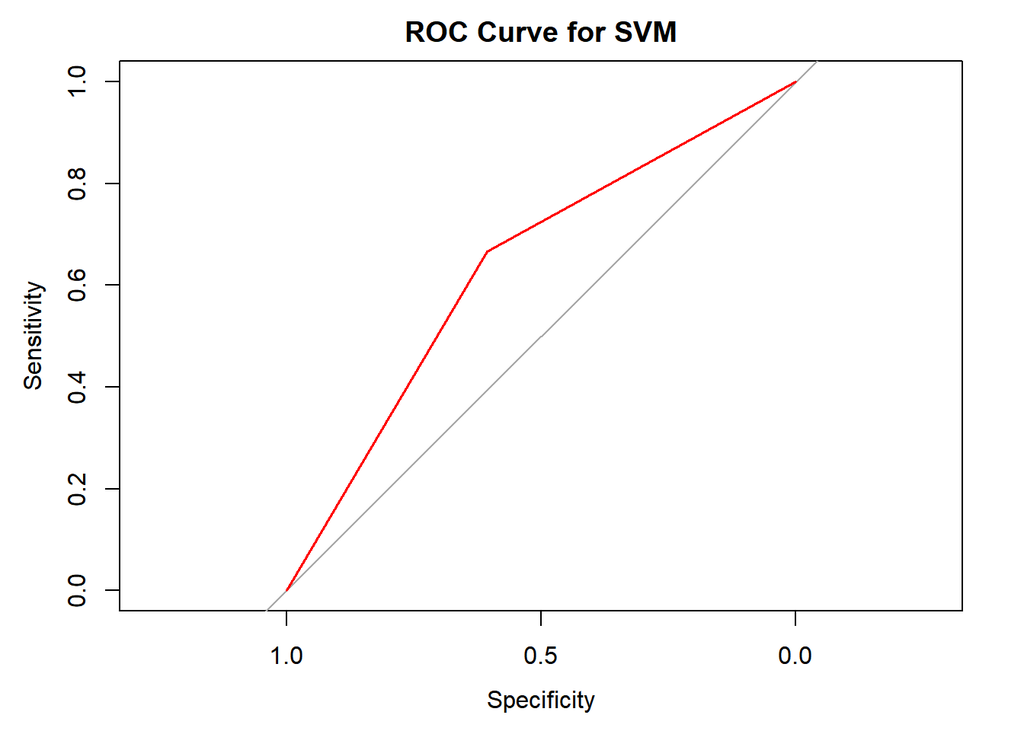

```
## Area under the curve: 0.6364
```